# Reproducible PENA Project Workflow

Phylogenetics and Systematics of Perennial Endemic North American (PENA) Clade of Apiaceae

Phebian Odufuwa

2020-12-02

# 1 Purpose

The purpose of this project is to develop a reproducible workflow in the R environment. The workflow developed for this project is specific to my research entitled **“Diversification in the Perennial Endemic North American (PENA) Clade of Apiaceae: Defining Genera and Species in A Major Western, North American Radiation”**, also known as *"The Phylogenetics and Systematics of PENA Clade of Apiaceae*.

**This work, however, is solely based on the first set of sequencing data that I have worked on.**

Deliverables related to this project include:

> - **Reproducible_Pena_Workflow.Rmd:** this document which details rationale for reproducible science, the project overview and data availability assessment, and a list of ways to ensure data reproducibility in this project.
> - **pena_proj_data_tree.Rmd:** this document was developed for visualization of project’s structure.
> - **Bioinformatics_Scripts.Rmd:** this document contains codes and scripts for my project.
> - **pena.bib:** A bibliography file which was created to better track citations. This file includes citations that are needed for all work during my research.
> - *other* **folders** *include:* **“Data”** (it contains aligned sequence data); **“Figures”** (it contains figures generated for project); **“PENA_Project”** (where the results of all analysis will be written into, see Figure 1 below); **“Protocols”** (which contains all the laboratory procedures followed for generating molecular data), and **“speciesinfo.csv”** file contains species information for 21 samples.

# 2 Introduction

Recently published literature (Baker, 2016) suggests that there is a reproducibility crisis in science. Barriers to reproducibility include:

> - **Selective reporting**
> - **Low statistical power**
> - **Not enough replication**
> - **Lack of documentation on methods / code used**
> - **Poor experimental design**
> - **Availability of raw data**

One way to overcome barriers to reproducibility is to participate in project planning and to focus on common errors and solutions to overcome those errors. Errors can be related to measurement, study design, replication, statistical analysis, analytical choices, citation bias, publication bias, interpretation and the misuse or neglect of simple mathematics (Brown *et al.*, 2018). According to Brown *et al.* (2018), several themes contribute to errors, and awareness of these themes can help overcome error and increase reproducibility. Themes contributing to errors include:

> - **Ignorance** - ignorance can occur at different levels within the project and may be propagated by poor examples in the literature. Errors related to ignorance can be difficult to identify, especially early in the research process.
> - **Poor Study Inception** - a poorly designed study leads to issues in the entire process.
> - **Expectations of Publication**
> - **Resources** - insufficient resources can foster errors.
> - **Conflicting Priorities**

While some of these themes are difficult to address, scientists can reduce errors related to these themes through several actions. Some actions that can reduce error production and increase reproducibility include: (see Brown *et al.* 2018; Baker, 2016):

> - **Project registration**
> - **Commitment to deposition of raw data and statistical code to public repositories**
> - **Normalizing error correction**
> - **Transparent study design and data management**

Some of these concepts will be applied to support the reproducibility of my dissertation research, which is focused on the phylogenetics and systematics of PENA clade of Apiaceae. The formal objectives of my research are to answer the following questions:

> - **Are genera within the PENA clade of Apiaceae monophyletic?**
> - **Are widespread species within the clade monophyletic?**
> - **What are the patterns of the evolution of morphological characters and biogeographical dispersal in the clade?**
> - **Should the species within the clade be revised and how should the results be disseminated?**
> - **How will a model genus within the clade respond to changing climate?**

# 3 Part One: Project Overview and Data Availability

Prior to initiating this project, a data management plan was absent and files were stored in a variety of locations. Following completion of this project, I will have built more structure and transparency into my research and will be in a better position to move forward.

To initiate this project, a brainstorming session was conducted where I generated a series of lists and broke my objectives into two categories of questions: phylogenetic and spatial. From there, I was able to identify questions that needed to be addressed by different datasets and start to identify the relationships within my data.

To determine how I can bring reproducibility to my research I first considered the overall data structure and my data needs which is the first step in transparent study design and data management. To help facilitate this, I wanted to visualize the general structure of my project and start to consider the relationships of my data.

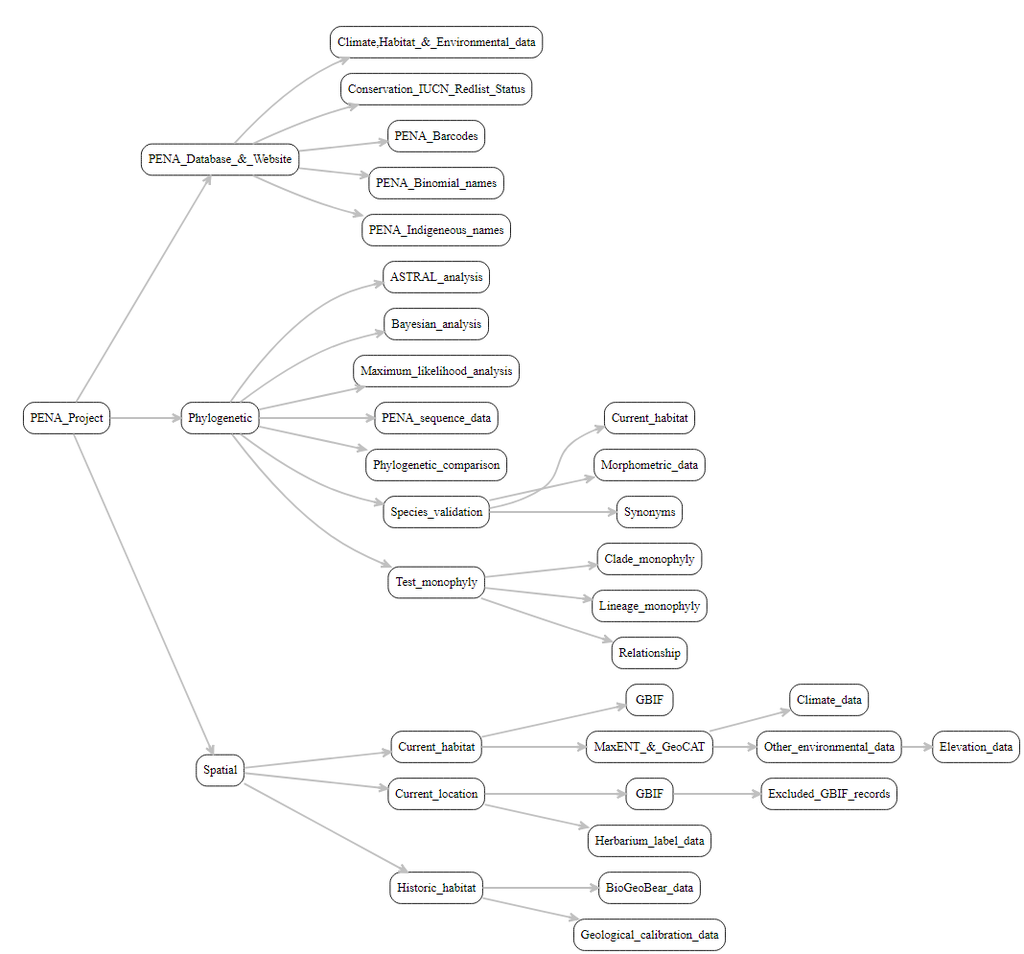

Figure 1: A preliminary data tree to visualize data structure

The data visualization process also helped me to identify which data are already available and which data I will be generating. My data tree can also serve as a starting point for discussion with my committee and will help me to identify areas of my own ignorance. I anticipate that this data structure will continue to be refined as my research progress and data needs both evolve.

**Data Sourcing Process:**

I identified several sources of pre-existing data which were located in a variety of locations. Some genetic sequence data is available from [GenBank](https://www.ncbi.nlm.nih.gov/genbank/) (Benson *et al*, 2013) and from our collaborators, but given I will be using much larger sets of molecular data, it is not likely that the pre-existing data can be used for my analyses. I can however compare my results to the results of previous works using these previously collected molecular markers to help understand my research outcomes.

A wealth of distribution and morphometric data are available from herbarium materials.  
Distribution data from the [Global Biodiversity Information Facility (GBIF)](https://www.gbif.org/) will be used for preliminary distribution mapping and environmental niche analysis. These data are known to have several source of error but these can be mostly overcome by cleaning options within the packages `"rgbif"` and `"CoordinateCleaner"`.

Another major source of data will be digitized herbarium specimens. These specimens will mostly be downloaded from [TROPICOS](http://www.tropicos.org/), but will also come from other digitization projects (e.g. [Snake River Plains Herbarium, The consortium of Pacific Northwest Herbaria](https://www.pnwherbaria.org/)). Morphometric data can be derived from the herbarium specimens and entered into a [Shiny tool](https://shiny.rstudio.com/) to ensure consistency. In addition to these open-source data sources, some data will be sourced from our collaborators. We currently have a Google drive, where we have all the the names of all our species stored, and where we collaborate from.

Going forward, data for my research will be stored in one location according to the predetermined data structure. Periodic data backups will be made to ensure that the data is safe from deletion, and versioning control using GitHub will be implemented.

# 4 Part Two: Plan to Ensure Data Reproducibility

To ensure reproducibility of my research, I will be as transparent as possible. This includes maintaining a logical data structure and controlling versions, setting hypotheses and objectives prior to initiating research, considering personal bias, and using open source products when available. I will endeavor to communicate all results, not only favorable or significant ones. I will help to create a place for collaboration and data sharing to avoid duplication and data management conflict. Given the experience with GitHub during the course of this class, I envision that creation of a GitHub page for collaboration is likely a good first step in facilitating communication among collaborators and others working with the 20 genera contained within the PENA clade of Apiaceae.

Following data collection, I will ensure that all genetic sequence data are deposited in the correct open source repositories (e.g. [GenBank](https://www.ncbi.nlm.nih.gov/genbank/) (Benson *et al.*, 2013)). Morphometric, bio-geographical and bioinformatic analyses will also be made public, likely through a platform such as [GitHub](https://github.com/phebianodufuwa), and a website will be established where all information about every species within the PENA clade of Apiaceae can be accessed for collaborations, for education purpose and for the public, especially to indigenous people who have constantly used these species for diverse purposes. Any specimens collected during the process of this research will be properly documented, pressed, digitized and made available to the public as soon as possible.

**Getting Started**

For this course’s individual project, I am focusing on 21 samples which I have NGS sequence data for.

# 5 Materials and Methods

## 5.1 Data Source

21 specimens , 20 were ingroup, and one was an outgroup (Table1). The source specimens were collected by my advisor and collaborators, and the vouchers were kept in Snake River Plain Herbarium, and in other herbaria. All vouchers information can be accessed from [here](https://www.pnwherbaria.org/data/providermetadata.php?code=CIC).

```r
## Import my species table as a .csv file into R
pena_table <- read.csv("speciesinfo.csv")
kable(pena_table, caption = "**Table 1.** Species information containing the barcode indexes for sequence data identification")
```

**Table 1.** Species information containing the barcode indexes for sequence data identification

| Species_names | Species_voucher | Index_1 | Index_2 |
| --- | --- | --- | --- |
| Angelica_arguta | DE_21178 | ATTACTCG | TATAGCCT |
| Cymopterus_nivalis | CEH_1348 | ATTACTCG | GGCTCTGA |
| Lomatium_andrusianum | JFS_13074 | CGCTCATT | GGCTCTGA |
| Lomatium_anomalum | DM_16095 | CGCTCATT | GTACTGAC |
| Lomatium_brandegeei | DM_11-472 | ATTACTCG | CAGGACGT |
| Lomatium_brevifolium | MS_110 | TCCGGAGA | CCTATCCT |
| Lomatium_geyeri | JFS_13066 | TCCGGAGA | GGCTCTGA |
| Lomatium_HM | DM_16020 | CGCTCATT | TAATCTTA |
| Lomatium_HM | JFS_13057 | ATTACTCG | AGGCGAAG |
| Lomatium_howellii | McNeill2016051509 | CGCTCATT | CCTATCCT |
| Lomatium_multifidum | Mancuso_4266 | CGCTCATT | ATAGAGGC |
| Lomatium_nudicaule | MS_112 | TCCGGAGA | GTACTGAC |
| Lomatium_nudicaule | WW_842 | ATTACTCG | ATAGAGGC |
| Lomatium_oreganum | Sines-sn | ATTACTCG | GTACTGAC |
| Lomatium_packardiae | MVO_186 | ATTACTCG | CCTATCCT |
| Lomatium_papilioniferum | DM_15-155 | TCCGGAGA | ATAGAGGC |
| Lomatium_peckianum | MD_1121 | CGCTCATT | CAGGACGT |
| Lomatium_simplex | DM_16094 | CGCTCATT | TATAGCCT |
| Lomatium_simplex | JFS_13393 | CGCTCATT | AGGCGAAG |
| Lomatium_tamanatchii | MD_624 | TCCGGAGA | TATAGCCT |
| Lomatium_HM | MF-sn | ATTACTCG | TAATCTTA |

### 5.1.1 DNA Extraction

Genomic DNA was extracted from the leaves and fruits of specimens preserved in silica gel and two from herbarium specimens using the Qiagen® Plant DNA extraction kit. All DNA extracts were quantified using a Qubit Fluorometer (Mardis, 2017), Nanodrop spectrophotometer was used to calculate the concentration of nucleic acids (260 nm) and purified proteins(280 nm). All protocols followed are located on the folder entitled **“Protocols”**

### 5.1.2 Library Preparation, Target Enrichment, and Sequencing

Sequence capture experiments have become very common among evolutionary biologists because of their high throughput, affordable prices, and the large amounts of data they produce. To get phylogenetic informative genes from the DNA of the samples I am working on, I am using the [target capture high throughput sequencing](https://www.idtdna.com/pages/technology/next-generation-sequencing/dna-sequencing/targeted-sequencing/hybridization-capture) approach. Therefore, extracted DNA were sent to [Arbor Biosciences®, Michigan](https://arborbiosci.com/?gclid=Cj0KCQiAzZL-BRDnARIsAPCJs73FMDKz0tKQ7CnZnuyCvWzBzxqaPvdoYtTy-Yv5XGVLtF75SNlT4M8aAs2DEALw_wcB) where DNA fragments were pooled and enriched with [Angiosperms353 baits](https://arborbiosci.com/genomics/targeted-sequencing/mybaits/mybaits-expert/mybaits-expert-angiosperms-353/) (Johnson *et al.*, 2019), multiplexed and sequenced on an [Illumina MiSeq with v3 (600 cycles as 2 x 300-bp paired-end reads)](https://www.illumina.com/systems/sequencing-platforms/miseq.html).

## 5.2 Data Processing

Due to the CPU memory load involved in sequence data analysis, all data are deposited and ran in a parallel computing cluster - the [BSU’s R2 Computing cluster](https://www.boisestate.edu/rcs/hpc/) running on a [Linux OS](https://www.linux.com/what-is-linux/), accessed remotely using a Secure Socket Shell (SSH). SSH is a network protocol that gives users, particularly system administrators, a secure way to access a computer over an unsecured network.

```bash
ssh podufuwa@r2.boisestate.edu
```

However, due to the number of users having access to the core processors, and using it at once, a job scheduling system known as [slurm](https://slurm.schedmd.com/overview.html) is used to submit all jobs. Therefore, I used the shell programming language to write all my scripts and submit my jobs through [slurm](https://slurm.schedmd.com/overview.html). All information on how to access this HPC computing is found [here](https://www.boisestate.edu/rcs/hpc/)

### 5.2.1 Bioinformatics

The reads from the sequencing output files ([FASTQ files](https://support.illumina.com/bulletins/2016/04/fastq-files-explained.html)) were checked for quality using FASTQC (Babraham, 2014). All reads with a Phred score (quality) below 33 were removed using [Trimmomatic](http://www.usadellab.org/cms/?page=trimmomatic) (Bolger *et al.*, 2014), in addition, all reads that were detected as unpaired were dropped. The read quality was then re-evaluated using [FASTQC](https://www.bioinformatics.babraham.ac.uk/projects/fastqc/) (Babraham, 2014) to ensure only high quality reads remained. [FASTQC](https://www.bioinformatics.babraham.ac.uk/projects/fastqc/) (Babraham, 2014) is a program designed to spot potential problems in high througput sequencing datasets. It runs a set of analyses on one or more raw sequence files in [fastq](https://support.illumina.com/bulletins/2016/04/fastq-files-explained.html) or [bam](https://support.illumina.com/help/BS_App_RNASeq_Alignment_OLH_1000000006112/Content/Source/Informatics/BAM-Format.htm) format and produces a report which summarizes the results.

Trimmed paired reads were processed using [HybPiper version 1.3.1](https://github.com/mossmatters/HybPiper) (Johnson *et al.*, 2016) to recover target sequences. HybPiper is a suite of Python scripts that wrap and organize bioinformatics tools for target sequence extraction from high-throughput sequencing reads. The primary output of the pipeline is a nucleotide and translated amino acid sequence for every gene that can be assembled from the sequencing reads. HybPiper also includes several post-processing scripts for retrieving sequences from multiple samples run through the pipeline, visualization of summary statistics such as recovery efficiency and coverage depth, and extraction of flanking intron sequences.

The HybPiper pipeline was set to use BLASTX (Camacho *et al.*, 2009) to map the reads to the reference target sequences (available at https://github.com/mossmatters/Angiosperms353; see Johnson *et al.*, 2019). Then, each gene was assembled *de novo* using SPAdes (Bankevich *et al.*, 2012), coding sequences were extracted using Exonerate (Slater & Birney, 2005), and non-coding sequences flanking the coding sequences were recovered using the script intronerate.py, part of HybPiper (Johnson *et al.*, 2016).

## 5.3 Phylogenetic Analysis

Alignment for phylogenetic analysis was done using [MAFFT](https://mafft.cbrc.jp/alignment/software/) (Katoh & Standley, 2005). For phylogenetic analysis, a maximum likelihood bootstrap tree was constructed with RAxML version 8 (Stamatakis, 2014), bootstrap replicate was set as 1000 to test the credibility of each clade. Bootstrap support value of >70% was used to test the reliability of clusters. To root the tree, one closely related species *Angelica arguta* Nutt. was used. Phylogenetic tree was visualized on FigTree v1.4.4 (Rambaut, 2018).

## 5.4 Scripting

For the purpose of reproducibility, all scripts are included in the [supplementary file](https://phebianodufuwa.github.io/Odufuwa_PENA_Project_Workflow/Bioinformatics_Scripts.html) entitled **“Bioinformatics_Scripts.Rmd”** and are annotated to indicate the purpose and function. All work in R language was done using R Studio (R Studio Team, 2015) and scripts are available in the [supplementary file](https://phebianodufuwa.github.io/Odufuwa_PENA_Project_Workflow/Bioinformatics_Scripts.html.

# 6 Results and Discussion

The results section is quite brief, because as at the time this analysis was done, what my advisor and I are interested in is a phylogenetic tree. However, the resources provided throughout the duration of this course, and the making of this Individual project will allow me to produce the statistical aspect and results of my research in a reproducible manner.

## 6.1 Length of sequences recovered

Figure 3 is the heat map showing the number of genes recovered by HybPiper using the Angiosperms 353 baits for 20 PENA species and one outgroup.

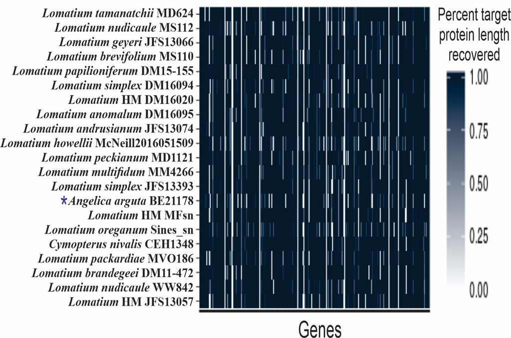

Figure 3. Heat map showing the number of genes recovered by HybPiper using the Angiosperms 353 baits for 20 PENA species and one outgroup (*). The shade of gray in the cell is determined by the length of sequence recovered

In the heat map, each row represents a sample, and each column represents a target. Each cell is shaded based on the length of the sequence recovered by HybPiper for that gene, as a percentage of the length of the reference sequence. The heat map can be used as a first glance at the efficiency of target recovery and help identify difficult-to-recover loci (columns with lighter shading) and low-enrichment samples (rows with lighter shading).

## 6.2 Phylogenetic analysis

Figure 4 shows the phylogenetic tree that was obtained from the phylogenetic analysis. My supervisor said the tree appears to conform with what was expected, however, more sampling of datasets is needed; something that will be done in later analysis.

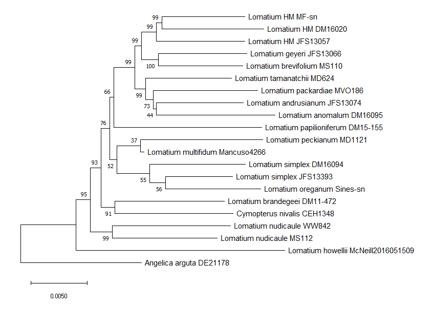

Figure 4. RAxML Phylogenetic tree for 20 PENA Species. Bootstrap value is indicated by the values on the branch, branch length does not represent absolute value, and the rate of substitution is indicated in the bar below the tree

# 7 Supplementary Material

The [supplementary material](https://phebianodufuwa.github.io/Odufuwa_PENA_Project_Workflow/Bioinformatics_Scripts.html) for this article can be found [here](https://phebianodufuwa.github.io/Odufuwa_PENA_Project_Workflow/Bioinformatics_Scripts.html)

# 8 References

Baker M. **2016.** 1,500 scientists lift the lid on reproducibility. *Nature* 533 (7604). Springer Nature: 452-54. doi:10.1038/533452a.

Brown AW, Kaiser KA, and Allison DB. **2018**. Issues with Data and Analyses: Errors, Underlying Themes, and Potential Solutions. *Proceedings of the National Academy of Sciences* 115 (11). National Academy of Sciences: 2563–70. doi:10.1073/pnas.1708279115.

Benson DA, Karsch-Mizrachi I, Lipman DJ, Ostell J, and Wheeler DL. **2005**. GenBank. *Nucleic Acids Research*. 2005 Jan 1;33(Database issue):D34-8. doi: 10.1093/nar/gki063.

Mardis E, and McCombie RW. **2017**. Library Quantification: Fluorometric Quantitation of Double_Stranded or Single-Stranded DNA Samples Using the Qubit System. *Cold Spring Habor Procol*. doi:10.1101/pdb.prot094730.

Johnson MG, Pokorny L, Dodsworth S, Botigué LR, Cowan RS, Devault A, Eiserhardt WL, Epitawalage N, Forest F, Kim JT, Leebens-Mack JH, Leitch IJ, Maurin O, Soltis DE, Soltis PS, Wong GK, Baker WJ, and Wickett NJ. **2019**. A Universal Probe Set for Targeted Sequencing of 353 Nuclear Genes from Any Flowering Plant Designed Using k-Medoids Clustering. *Systematic Biology* Volume 68, Issue 4, Pages 594–606. doi.org/10.1093/sysbio/syy086.

Babraham Bioinformatics. **2014**. FastQC: A Quality Control Tool for High Throughput Sequence Data.

Bolger AM, Lohse M, and Usadel B. **2014**. Trimmomatic: a flexible trimmer for Illumina sequence data. *Bioinformatics*. 2014 Aug 1;30(15):2114-20. doi: 10.1093/bioinformatics/btu170.

Johnson MG, Gardner EM, Liu Y, Medina R, Goffinet B, Shaw AJ, Zerega NJ, and Wickett NJ. **2016**. HybPiper: Extracting coding sequence and introns for phylogenetics from high-throughput sequencing reads using target enrichment. *Applications in Plant Sciences*;4(7):apps.1600016. doi: 10.3732/apps.1600016.

van Rossum G, and Drake FL. 2014. *The Python Language Reference Manual*. Network Theory Ltd.

Camacho C, Coulouris G, Avagyan V, Ma N, Papadopoulos J, Bealer K, and Madden TL. **2009.** BLAST+: architecture and applications. *BMC Bioinformatics* 10, 421. doi.org/10.1186/1471-2105-10-421.

Slater GSC, and Birney E. **2005.** Automated generation of heuristics for biological sequence comparison. *BMC Bioinformatics* 6, 31. doi.org/10.1186/1471-2105-6-31.

Katoh K, and Standley DM. **2013.** MAFFT Multiple Sequence Alignment Software Version 7: Improvements in Performance and Usability. *Molecular Biology and Evolution*. 30, 4: 772–780. doi.org/10.1093/molbev/mst010.

Stamatakis A. **2014**. RAxML version 8: a tool for phylogenetic analysis and post-analysis of large phylogenies. *Bioinformatics*, 30, 9: 1312–1313. doi.org/10.1093/bioinformatics/btu033.

Rambaut A. **2018**. *FigTree v 1.4.2, a graphical viewer of phylogenetic trees.

Li H, and Durbin R. **2009**. Fast and accurate short read alignment with Burrows_Wheeler transform. *Bioinformatics*, 25, 14: 1754-1760. doi.org/10.1093/bioinformatics/btp324.

# 9 Appendix 1

Citations of all R packages used to generate this report.

[1] J. Allaire, Y. Xie, J. McPherson, et al. *rmarkdown: Dynamic Documents for R*. R package version 2.5. 2020. <URL: https://github.com/rstudio/rmarkdown>.

[2] B. Auguie. *gridExtra: Miscellaneous Functions for “Grid” Graphics*. R package version 2.3. 2017. <URL: https://CRAN.R-project.org/package=gridExtra>.

[3] C. Boettiger. *knitcitations: Citations for Knitr Markdown Files*. R package version 1.0.10. 2019. <URL: https://github.com/cboettig/knitcitations>.

[4] J. Cheng, C. Sievert, W. Chang, et al. *htmltools: Tools for HTML*. R package version 0.5.0. 2020. <URL: https://github.com/rstudio/htmltools>.

[5] I. Lyttle. *vembedr: Embed Video in HTML*. R package version 0.1.4. 2020. <URL: https://github.com/ijlyttle/vembedr>.

[6] Y. Qiu. *prettydoc: Creating Pretty Documents from R Markdown*. R package version 0.4.0. 2020. <URL: https://github.com/yixuan/prettydoc>.

[7] R Core Team. *R: A Language and Environment for Statistical Computing*. R Foundation for Statistical Computing. Vienna, Austria, 2020. <URL: https://www.R-project.org/>.

[8] K. Ushey, J. McPherson, J. Cheng, et al. *packrat: A Dependency Management System for Projects and their R Package Dependencies*. R package version 0.5.0. 2018. <URL: https://github.com/rstudio/packrat/>.

[9] G. R. Warnes, B. Bolker, L. Bonebakker, et al. *gplots: Various R Programming Tools for Plotting Data*. R package version 3.1.0. 2020. <URL: https://github.com/talgalili/gplots>.

[10] H. Wickham. *ggplot2: Elegant Graphics for Data Analysis*. Springer-Verlag New York, 2016. ISBN: 978-3-319-24277-4. <URL: https://ggplot2.tidyverse.org>.

[11] H. Wickham. *reshape2: Flexibly Reshape Data: A Reboot of the Reshape Package*. R package version 1.4.4. 2020. <URL: https://github.com/hadley/reshape>.

[12] H. Wickham. “Reshaping Data with the reshape Package”. In: *Journal of Statistical Software* 21.12 (2007), pp. 1-20. <URL: http://www.jstatsoft.org/v21/i12/>.

[13] H. Wickham and J. Bryan. *usethis: Automate Package and Project Setup*. R package version 1.6.3. 2020. <URL: https://CRAN.R-project.org/package=usethis>.

[14] H. Wickham, W. Chang, L. Henry, et al. *ggplot2: Create Elegant Data Visualisations Using the Grammar of Graphics*. R package version 3.3.2. 2020. <URL: https://CRAN.R-project.org/package=ggplot2>.

[15] H. Wickham, R. FranÃ§ois, L. Henry, et al. *dplyr: A Grammar of Data Manipulation*. R package version 1.0.2. 2020. <URL: https://CRAN.R-project.org/package=dplyr>.

[16] H. Wickham, J. Hester, and W. Chang. *devtools: Tools to Make Developing R Packages Easier*. R package version 2.3.2. 2020. <URL: https://CRAN.R-project.org/package=devtools>.

[17] Y. Xie. *bookdown: Authoring Books and Technical Documents with R Markdown*. ISBN 978-1138700109. Boca Raton, Florida: Chapman and Hall/CRC, 2016. <URL: https://github.com/rstudio/bookdown>.

[18] Y. Xie. *bookdown: Authoring Books and Technical Documents with R Markdown*. R package version 0.20. 2020. <URL: https://github.com/rstudio/bookdown>.

[19] Y. Xie. *Dynamic Documents with R and knitr*. 2nd. ISBN 978-1498716963. Boca Raton, Florida: Chapman and Hall/CRC, 2015. <URL: https://yihui.org/knitr/>.

[20] Y. Xie. *formatR: Format R Code Automatically*. R package version 1.7. 2019. <URL: https://github.com/yihui/formatR>.

[21] Y. Xie. “knitr: A Comprehensive Tool for Reproducible Research in R”. In: *Implementing Reproducible Computational Research*. Ed. by V. Stodden, F. Leisch and R. D. Peng. ISBN 978-1466561595. Chapman and Hall/CRC, 2014. <URL: http://www.crcpress.com/product/isbn/9781466561595>.

[22] Y. Xie. *knitr: A General-Purpose Package for Dynamic Report Generation in R*. R package version 1.30. 2020. <URL: https://yihui.org/knitr/>.

[23] Y. Xie, J. Allaire, and G. Grolemund. *R Markdown: The Definitive Guide*. ISBN 9781138359338. Boca Raton, Florida: Chapman and Hall/CRC, 2018. <URL: https://bookdown.org/yihui/rmarkdown>.

[24] Y. Xie, C. Dervieux, and E. Riederer. *R Markdown Cookbook*. ISBN 9780367563837. Boca Raton, Florida: Chapman and Hall/CRC, 2020. <URL: https://bookdown.org/yihui/rmarkdown-cookbook>.

[25] H. Zhu. *kableExtra: Construct Complex Table with kable and Pipe Syntax*. R package version 1.3.1. 2020. <URL: https://CRAN.R-project.org/package=kableExtra>.

# 10 Appendix 2

Version information about R, the operating system (OS) and attached or R loaded packages. This appendix was generated using `sessionInfo()`.

[session information not shown]